# 빅데이터분석특강 기말고사

## imports

```python
import numpy as np
import matplotlib.pyplot as plt
import tensorflow as tf
import tensorflow.experimental.numpy as tnp
```

```python
tnp.experimental_enable_numpy_behavior()
```

```python
%load_ext tensorboard
```

```
The tensorboard extension is already loaded. To reload it, use:
  %reload_ext tensorboard
```

```python
%tensorflow_version 2.x
import tensorflow as tf
device_name = tf.test.gpu_device_name()
if device_name != '/device:GPU:0':
  raise SystemError('GPU device not found')
print('Found GPU at: {}'.format(device_name))
```

```
Found GPU at: /device:GPU:0
```

```python
import graphviz
def gv(s): return graphviz.Source('digraph G{ rankdir="LR"'+ s + ';}')
```

## 1. Fashion_mnist, DNN (30점)

```python
#collapse
gv('''
splines=line
subgraph cluster_1{
    style=filled;
    color=lightgrey;
    "x1"
    "x2"
    ".."
    "x784"
    label = "Layer 0"
}
subgraph cluster_2{
    style=filled;
    color=lightgrey;
    "x1" -> "node1"
    "x2" -> "node1"
    ".." -> "node1"
    "x784" -> "node1"

    "x1" -> "node2"
    "x2" -> "node2"
    ".." -> "node2"
    "x784" -> "node2"

    "x1" -> "..."
    "x2" -> "..."
    ".." -> "..."
    "x784" -> "..."

    "x1" -> "node20"
    "x2" -> "node20"
    ".." -> "node20"
    "x784" -> "node20"


    label = "Layer 1: relu"
}
subgraph cluster_3{
    style=filled;
    color=lightgrey;
    "node1" -> "node1 "
    "node2" -> "node1 "
    "..." -> "node1 "
    "node20" -> "node1 "

    "node1" -> "node2 "
    "node2" -> "node2 "
    "..." -> "node2 "
    "node20" -> "node2 "

    "node1" -> "... "
    "node2" -> "... "
    "..." -> "... "
    "node20" -> "... "

    "node1" -> "node30 "
    "node2" -> "node30 "
    "..." -> "node30 "
    "node20" -> "node30 "


    label = "Layer 2: relu"
}
subgraph cluster_4{
    style=filled;
    color=lightgrey;

    "node1 " -> "y10"
    "node2 " -> "y10"
    "... " -> "y10"
    "node30 " -> "y10"

    "node1 " -> "y1"
    "node2 " -> "y1"
    "... " -> "y1"
    "node30 " -> "y1"

    "node1 " -> "."
    "node2 " -> "."
    "... " -> "."
    "node30 " -> "."

    label = "Layer 3: softmax"
}
''')
```

[figure not shown]

`(1)` `tf.keras.datasets.fashion_mnist.load_data()`을 이용하여 fashion_mnist 자료를 불러온 뒤 아래의 네트워크를 이용하여 적합하라. (6점)

- 평가지표로 accuracy를 이용할 것
- epoch은 10으로 설정할 것
- optimizer는 adam을 이용할 것

### Solution

```python
(x_train, y_train), (x_test, y_test) = tf.keras.datasets.fashion_mnist.load_data()
```

```python
X= tf.constant(x_train.reshape(-1,28,28,1),dtype=tf.float64)
y = tf.keras.utils.to_categorical(y_train)
XX = tf.constant(x_test.reshape(-1,28,28,1),dtype=tf.float64)
yy = tf.keras.utils.to_categorical(y_test)
```

```python
X.shape,XX.shape,y.shape, yy.shape
```

```
(TensorShape([60000, 28, 28, 1]),
 TensorShape([10000, 28, 28, 1]),
 (60000, 10),
 (10000, 10))
```

```python
with tf.device("/device:GPU:0") :
    tf.random.set_seed(202150256)

    net1 = tf.keras.Sequential()
    net1.add(tf.keras.layers.Flatten())
    net1.add(tf.keras.layers.Dense(20,activation="relu"))
    net1.add(tf.keras.layers.Dense(30,activation="relu"))
    net1.add(tf.keras.layers.Dense(10,activation="softmax"))
    net1.compile(optimizer="adam",loss=tf.losses.categorical_crossentropy,metrics=["accuracy"])
    net1.fit(X,y,epochs=10,verbose=1)
```

`(2)` (1)에서 적합된 네트워크를 이용하여 test data의 accuracy를 구하라. (6점)

### Solution

```python
result1 = net1.evaluate(XX,yy)
```

[output not shown]

`(3)` train set에서 20%의 자료를 validation 으로 분리하여 50에폭동안 학습하라. 텐서보드를 이용하여 train accuracy와 validation accuracy를 시각화 하고 결과를 해석하라. 오버피팅이라고 볼 수 있는가? (6점)

### Solution

```python
tf.random.set_seed(202150256)
!rm -rf logs
with tf.device("/device:GPU:0") :
    net2 = tf.keras.Sequential()
    net2.add(tf.keras.layers.Flatten())
    net2.add(tf.keras.layers.Dense(20,activation="relu"))
    net2.add(tf.keras.layers.Dense(30,activation="relu"))
    net2.add(tf.keras.layers.Dense(10,activation="softmax"))
    net2.compile(optimizer="adam",loss=tf.losses.categorical_crossentropy,metrics=["accuracy"])
    cb1 = tf.keras.callbacks.TensorBoard()
    net2.fit(X,y,epochs=50,validation_split=0.2,callbacks=cb1,verbose=0)
```

```python
%tensorboard --logdir logs
```

```
Output hidden; open in https://colab.research.google.com to view.
```

`-` 오버피팅이 아니다. `accuracy`와 `loss`를 살펴본 결과 에포크가 증가할 수록 `train data`와 `validation data`에 대한 `accuracy`, `loss` 비슷하며 심지어 `validation data` 더 뛰어난 성능을 보이는 구간도 존재한다.

`(4)` (3)에서 적합된 네트워크를 이용하여 test data의 accuracy를 구하라. (2)의 결과와 비교하라. (6점)

### Solution

```python
result2 = net2.evaluate(XX,yy)
```

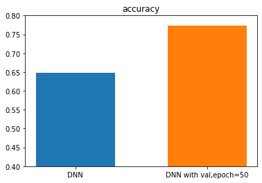

```python
x = ["DNN","DNN with val,epoch=50"]
acc = [result1[1],result2[1]]

plt.bar(x[0],acc[0],width=0.6)
plt.bar(x[1],acc[1],width=0.6)
plt.ylim([0.4,0.8])
plt.title("accuracy")
```

- epoch 수와 validation data를 추가하여 학습한 모델이 test데이터에 대한 정확도가 더 높았다.

`(5)` 조기종료기능을 이용하여 (3)의 네트워크를 다시 학습하라. 학습결과를 텐서보드를 이용하여 시각화 하라. (6점)

- patience=3 으로 설정할 것

### Solution

```python
tf.random.set_seed(202150256)
!rm -rf logs
with tf.device("/device:GPU:0") :
    net3 = tf.keras.Sequential()
    net3.add(tf.keras.layers.Flatten())
    net3.add(tf.keras.layers.Dense(20,activation="relu"))
    net3.add(tf.keras.layers.Dense(30,activation="relu"))
    net3.add(tf.keras.layers.Dense(10,activation="softmax"))
    net3.compile(optimizer="adam",loss=tf.losses.categorical_crossentropy,metrics=["accuracy"])
    cb1 = tf.keras.callbacks.TensorBoard()
    cb2 = tf.keras.callbacks.EarlyStopping(patience=3)
    net3.fit(X,y,epochs=50,validation_split=0.2,callbacks=[cb1,cb2],verbose=0)
```

```python
%tensorboard --logdir logs
```

```
Output hidden; open in https://colab.research.google.com to view.
```

## 2. Fashion_mnist, CNN (30점)

`(1)` `tf.keras.datasets.fashion_mnist.load_data()`을 이용하여 fashion_mnist 자료를 불러온 뒤 아래의 네트워크를 이용하여 적합하라. (10점)

- 이때 n1=6, n2=16, n3=120 으로 설정한다, 드랍아웃비율은 20%로 설정한다.
- `net.summary()`를 출력하여 설계결과를 확인하라.

[figure not shown]

### Solution

```python
!rm -rf logs
with tf.device("/device:GPU:0") :
    net4 = tf.keras.Sequential()
    net4.add(tf.keras.layers.Conv2D(6,(5,5)))
    net4.add(tf.keras.layers.MaxPool2D())
    net4.add(tf.keras.layers.Conv2D(16,(5,5)))
    net4.add(tf.keras.layers.MaxPool2D())
    net4.add(tf.keras.layers.Flatten())
    net4.add(tf.keras.layers.Dense(120,activation="relu"))
    net4.add(tf.keras.layers.Dropout(0.2))
    net4.add(tf.keras.layers.Dense(10,activation="softmax"))
    net4.compile(optimizer="adam",loss=tf.losses.categorical_crossentropy,metrics="accuracy")
    net4.fit(X,y,epochs=1,verbose=0)
```

```python
net4.summary()
```

```
Model: "sequential_72"
_________________________________________________________________
 Layer (type)                Output Shape              Param #
=================================================================
 conv2d_139 (Conv2D)         (32, 24, 24, 6)           156

 max_pooling2d_108 (MaxPooli  (32, 12, 12, 6)          0
 ng2D)

 conv2d_140 (Conv2D)         (32, 8, 8, 16)            2416

 max_pooling2d_109 (MaxPooli  (32, 4, 4, 16)           0
 ng2D)

 flatten_70 (Flatten)        (32, 256)                 0

 dense_158 (Dense)           (32, 120)                 30840

 dropout_50 (Dropout)        (32, 120)                 0

 dense_159 (Dense)           (32, 10)                  1210

=================================================================
Total params: 34,622
Trainable params: 34,622
Non-trainable params: 0
_________________________________________________________________
```

`(2)` n1=(6,64,128), n2=(16,256)에 대하여 test set의 loss가 최소화되는 조합을 찾아라. 결과를 텐서보드로 시각화하는 코드를 작성하라. (20점)

- epoc은 3회로 한정한다.
- validation_split은 0.2로 설정한다.

### Solution

```python
from tensorboard.plugins.hparams import api as hp
```

```python
!rm -rf logs
N1= [6,64,128]
N2= [16,256]
for n1 in N1 :
    for n2 in N2 :
      logdir =  "logs/gc_{}_{}".format(n1,n2)
      with tf.summary.create_file_writer(logdir).as_default() :
           with tf.device("/device:GPU:0") :
              net5 = tf.keras.Sequential()
              net5.add(tf.keras.layers.Conv2D(n1,(5,5)))
              net5.add(tf.keras.layers.MaxPool2D())
              net5.add(tf.keras.layers.Conv2D(n2,(5,5)))
              net5.add(tf.keras.layers.MaxPool2D())
              net5.add(tf.keras.layers.Flatten())
              net5.add(tf.keras.layers.Dense(120,activation="relu"))
              net5.add(tf.keras.layers.Dropout(0.2))
              net5.add(tf.keras.layers.Dense(10,activation="softmax"))
              net5.compile(optimizer="adam",loss=tf.losses.categorical_crossentropy,metrics="accuracy")
              cb3 = hp.KerasCallback(logdir,{"n1":n1,"n2":n2})
              net5.fit(X,y,epochs=3, validation_split=0.2,callbacks=cb3,verbose=0,batch_size=200)
              _result = net5.evaluate(XX,yy)
              tf.summary.scalar('loss', _result[0], step=1)
```

```python
%tensorboard --logdir logs
```

```
Output hidden; open in https://colab.research.google.com to view.
```

- $n_1 = 6, n_2 = 256$인 경우가 가장 test loss가 작았다.

## 3. CIFAR10 (30점)

`tf.keras.datasets.cifar10.load_data()`을 이용하여 CIFAR10을 불러온 뒤 적당한 네트워크를 사용하여 적합하라.

- 결과를 텐서보드로 시각화할 필요는 없다.
- 자유롭게 모형을 설계하여 적합하라.
- test set의 accuracy가 70%이상인 경우만 정답으로 인정한다.

### Solution

```python
(x_train, y_train), (x_test, y_test) = tf.keras.datasets.cifar10.load_data()
```

```python
X = tf.constant(x_train.reshape(-1,32,32,3),dtype=tf.float64)
y = tf.keras.utils.to_categorical(y_train)
XX = tf.constant(x_test.reshape(-1,32,32,3),dtype=tf.float64)
yy = tf.keras.utils.to_categorical(y_test)
```

```python
tf.random.set_seed(202150256)
!rm -rf logs
with tf.device("/device:GPU:0") :
    net6 = tf.keras.Sequential()
    net6.add(tf.keras.layers.Conv2D(128, (2, 2), activation='relu'))
    net6.add(tf.keras.layers.MaxPooling2D((2, 2)))
    net6.add(tf.keras.layers.Conv2D(128, (2, 2), activation='relu'))
    net6.add(tf.keras.layers.MaxPooling2D((2, 2)))
    net6.add(tf.keras.layers.Conv2D(256, (2, 2), activation='relu'))
    net6.add(tf.keras.layers.MaxPooling2D((2, 2)))
    net6.add(tf.keras.layers.Conv2D(256, (2, 2), activation='relu'))
    net6.add(tf.keras.layers.Flatten())
    net6.add(tf.keras.layers.Dense(512, activation='relu'))
    net6.add(tf.keras.layers.Dropout(0.5))
    net6.add(tf.keras.layers.Dense(10, activation='softmax'))
    net6.compile(optimizer="adam",loss=tf.losses.categorical_crossentropy,metrics="accuracy")
    net6.fit(X,y,epochs=10,verbose=0,batch_size=200)
```

```python
result6 = net6.evaluate(XX,yy)
```

[output not shown]

## 4. 다음을 읽고 물음에 답하라. (10점)

(1) (1,128,128,3)의 shape을 가진 텐서가 `tf.keras.layers.Conv2D(5,(2,2))`으로 만들어진 커널을 통과할시 나오는 shape은?

### Solution

```python
XXX = tnp.arange(1*128*128*3,dtype= tf.float64).reshape(1,128,128,3)
cv1 = tf.keras.layers.Conv2D(5,(2,2))
cv1(XXX).shape
```

```
TensorShape([1, 127, 127, 5])
```

(1,127,127,5)

(2) (1,24,24,16)의 shape을 가진 텐서가 `tf.keras.layers.Flatten()`을 통과할때 나오는 텐서의 shape은?

### Solution

```python
XXX = tnp.arange(1*24*24*16,dtype= tf.float64).reshape(1,24,24,16)
flttn = tf.keras.layers.Flatten()
flttn(XXX).shape
```

```
TensorShape([1, 9216])
```

(1,9216)

(3) 관측치의 수가 10인 자료에서 batch_size=3으로 설정하면 한 에폭당 몇번의 이터레이션이 수행되는가?

### Solution

```python
t= np.array(range(10))* np.pi/1000
y = -2+ 3*np.cos(t) + 1*np.cos(2*t) + 0.5*np.cos(5*t) + np.random.randn(10)*0.2

y = y.reshape(10,1)
x1 = np.cos(t)
x2 = np.cos(2*t)
x3 = np.cos(3*t)
x4 = np.cos(4*t)
x5 = np.cos(5*t)
X = tf.stack([x1,x2,x3,x4,x5],axis=1)
```

```python
net = tf.keras.Sequential()
net.add(tf.keras.layers.Dense(1))
net.compile(loss='mse',optimizer='sgd')
net.fit(X,y,batch_size=3, epochs = 2, verbose=1)
```

[output not shown]

```
<keras.callbacks.History at 0x7fe2009e25d0>
```

(4) 적당한 선형변환을 적용하여 (28,28)의 크기를 가진 흑백이미지를 (27,27)의 크기를 가지는 흑백이미지로 바꾸려 한다. (2,2) 크기의 커널을 가진 Conv2D layer를 이용한다면 몇개의 가중치가 필요한가? (바이어스는 무시한다)

### Solution

```python
XXX = tnp.arange(1*28*28*1,dtype= tf.float64).reshape(1,28,28,1)
cv1 = tf.keras.layers.Conv2D(1,(2,2))
```

```python
cv1(XXX).shape
```

```
TensorShape([1, 27, 27, 1])
```

```python
cv1.weights[0]
```

```
<tf.Variable 'conv2d_158/kernel:0' shape=(2, 2, 1, 1) dtype=float32, numpy=
array([[[[ 0.25548106]],

        [[-0.40794522]]],


       [[[ 0.691039  ]],

        [[ 0.81598204]]]], dtype=float32)>
```

4

(5) 적당한 선형변환을 적용하여 (28,28)의 크기를 가진 흑백이미지를 (27,27)의 크기를 가지는 흑백이미지로 바꾸려 한다. Dense layer를 이용한다면 몇개의 가중치가 필요한가? (바이어스는 무시한다)

```python
XXX = tnp.arange(1*28*28*1,dtype= tf.float64).reshape(1,28,28,1)
d = tf.keras.layers.Dense(1)
```

```python
d(flttn(XXX))
```

```
<tf.Tensor: shape=(1, 1), dtype=float32, numpy=array([[-333.56744]], dtype=float32)>
```

```python
d.weights
```

[output not shown]

- 픽셀은 못바꾸지 않나...???